# Tutorial: bulk RNA-seq differential expression with edgeR

Author

Affiliation

Lieven Clement

Ghent University

```r
library(tidyverse)
library(edgeR)
library(data.table)
library(ExploreModelMatrix)
library(patchwork)
```

# 1 Background

Influenza A virus infects the lungs, but patients often also report neurological symptoms. Blackmore et al. (2017) studied how a peripheral influenza infection affects the central nervous system in mice. They infected 8-week-old C57BL/6 mice intranasally with influenza A and sequenced the RNA of the cerebellum and the spinal cord of

- non-infected mice (day 0),
- mice 4 days after infection, i.e. around the peak of the infection in the lungs,
- mice 8 days after infection, i.e. when the virus is being cleared by the adaptive immune response.

Both female and male mice were used. The data are available in GEO under accession number GSE96870. The reads were aligned to the mouse genome with STAR and the reads that map to each gene were counted. We use the count table of the cerebellum that the Carpentries prepared for their lesson [RNA-seq analysis with Bioconductor](https://carpentries-incubator.github.io/bioc-rnaseq/).

Research questions:

1. Is there an early effect of the infection (day 4 vs day 0) in female mice? And in male mice?
2. Is there a late effect of the infection (day 8 vs day 0) in female mice? And in male mice?
3. Does the expression change between the early and the late phase (day 8 vs day 4) in female mice? And in male mice?
4. Do these effects differ between the sexes, i.e. is there a sex $\times$ time interaction for the early effect, for the late effect and for the change between the early and the late phase?
5. What are the average early effect, late effect and change between the early and late phase over both sexes?
6. Is there a difference between male and female mice before the infection (day 0)?

# 2 Data import

We read the count table, the sample information and the gene annotation directly from the GitHub repository of the Carpentries lesson. The `fread` function of the data.table package detects the format of the file (separator, header, column types) automatically, so the same function reads both the comma-separated (`.csv`) and the tab-separated (`.tsv`) files.

```r
dataUrl <- paste0("https://github.com/carpentries-incubator/",
                  "bioc-rnaseq/raw/main/episodes/data/")
counts <- fread(paste0(dataUrl, "GSE96870_counts_cerebellum.csv"), data.table = FALSE) |>
  column_to_rownames("gene")
coldata <- fread(paste0(dataUrl, "GSE96870_coldata_cerebellum.csv"), data.table = FALSE)
rowdata <- fread(paste0(dataUrl, "GSE96870_rowranges.tsv"), data.table = FALSE) |>
  mutate(ENTREZID = as.character(ENTREZID))
dim(counts)
```

```
[1] 41786    22
```

```r
counts[1:3, 1:4]
```

```
             GSM2545336 GSM2545337 GSM2545338 GSM2545339
Xkr4               1891       2410       2159       1980
LOC105243853          0          0          1          4
LOC105242387        204        121        110        120
```

```r
coldata |>
  select(sample, title, sex, infection, time, mouse) |>
  head()
```

```
      sample           title    sex   infection time mouse
1 GSM2545336 CNS_RNA-seq_10C Female  InfluenzaA Day8    14
2 GSM2545337 CNS_RNA-seq_11C Female NonInfected Day0     9
3 GSM2545338 CNS_RNA-seq_12C Female NonInfected Day0    10
4 GSM2545339 CNS_RNA-seq_13C Female  InfluenzaA Day4    15
5 GSM2545340 CNS_RNA-seq_14C   Male  InfluenzaA Day4    18
6 GSM2545341 CNS_RNA-seq_17C   Male  InfluenzaA Day8     6
```

The columns of the count table are in the same order as the rows of the sample information.

```r
all(colnames(counts) == coldata$sample)
```

```
[1] TRUE
```

We make factors for sex and time and choose day 0 as the reference level for time.

```r
coldata <- coldata |>
  mutate(
    sex = factor(sex),
    time = factor(time, levels = c("Day0", "Day4", "Day8")),
    infection = factor(infection, levels = c("NonInfected", "InfluenzaA"))
  )
table(coldata$sex, coldata$time)
```

```
         Day0 Day4 Day8
  Female    4    4    4
  Male      3    4    3
```

```r
table(coldata$infection, coldata$time)
```

```
              Day0 Day4 Day8
  NonInfected    7    0    0
  InfluenzaA     0    8    7
```

**TipQuestion**

- What is the experimental unit?
- Every mouse contributes one sample. What does this imply for the design?
- Can we estimate the effect of the infection separately from the effect of time?
- Each sample comes from a different mouse: the mouse is the experimental unit and the design is a completely randomised $2 \times 3$ factorial design with sex and time as factors.
- There is no blocking factor, unlike the macrophage experiment in the lecture, where every donor was exposed to all four treatments.
- All non-infected mice were sacrificed at day 0 and all infected mice at day 4 or 8: infection and time are completely confounded. The variable `infection` does not contain information that is not already in `time`, so we only use `time` in the model. The comparison day 4 vs day 0 is the effect of 4 days of infection.

# 3 Warm-up: sex differences before the infection

We first get acquainted with the workflow on a simple two-group comparison: female vs male mice before the infection (day 0). This comparison has a known answer: genes on the Y chromosome are only expressed in males and *Xist*, which inactivates one of the two X chromosomes, only in females. It therefore serves as a positive control: if the workflow does not find these genes, something went wrong.

## 3.1 Construct the DGEList

We select the day-0 mice and store their counts, sample information and gene annotation in a `DGEList` object.

```r
day0 <- coldata$time == "Day0"
dge0 <- DGEList(
  counts = counts[, day0],
  samples = coldata[day0, ],
  genes = rowdata[match(rownames(counts), rowdata$gene), c("gene", "seqnames", "ENTREZID")]
)
table(dge0$samples$sex)
```

```
Female   Male
     4      3
```

## 3.2 Library sizes

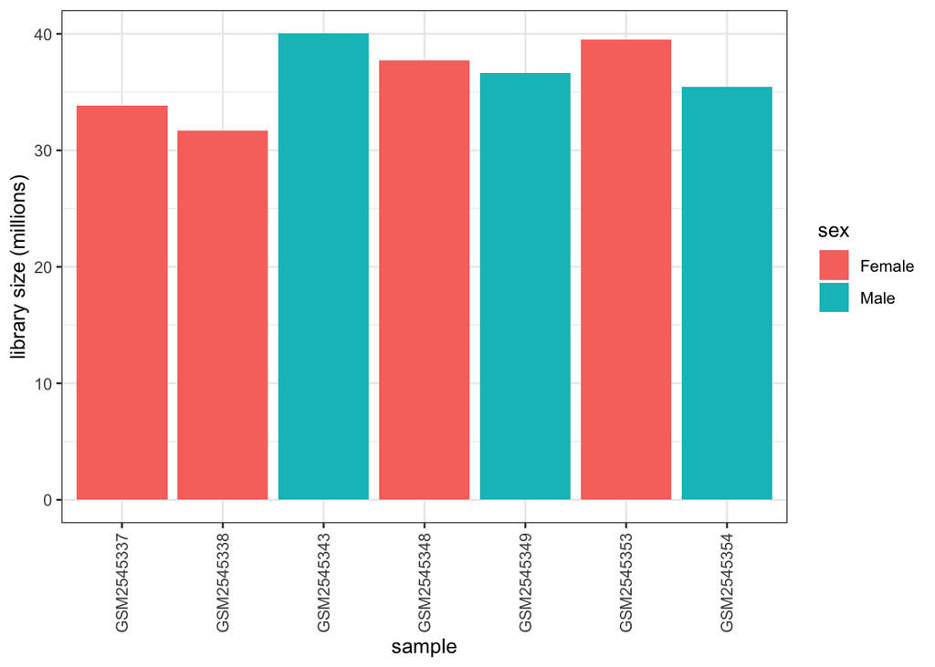

```r
dge0$samples |>
  mutate(sample = colnames(dge0), libSize = lib.size / 1e6) |>
  ggplot(aes(sample, libSize, fill = sex)) +
  geom_col() +
  ylab("library size (millions)") +
  theme_bw() +
  theme(axis.text.x = element_text(angle = 90, vjust = 0.5, hjust = 1))
```

## 3.3 Filtering and normalisation

```r
design0 <- model.matrix(~ sex, data = dge0$samples)
design0
```

```
           (Intercept) sexMale
GSM2545337           1       0
GSM2545338           1       0
GSM2545343           1       1
GSM2545348           1       0
GSM2545349           1       1
GSM2545353           1       0
GSM2545354           1       1
attr(,"assign")
[1] 0 1
attr(,"contrasts")
attr(,"contrasts")$sex
[1] "contr.treatment"
```

```r
keep0 <- filterByExpr(dge0, design0)
table(keep0)
```

```
keep0
FALSE  TRUE
24007 17779
```

```r
dge0 <- dge0[keep0, , keep.lib.sizes = FALSE]
dge0 <- normLibSizes(dge0)
```

## 3.4 Data exploration

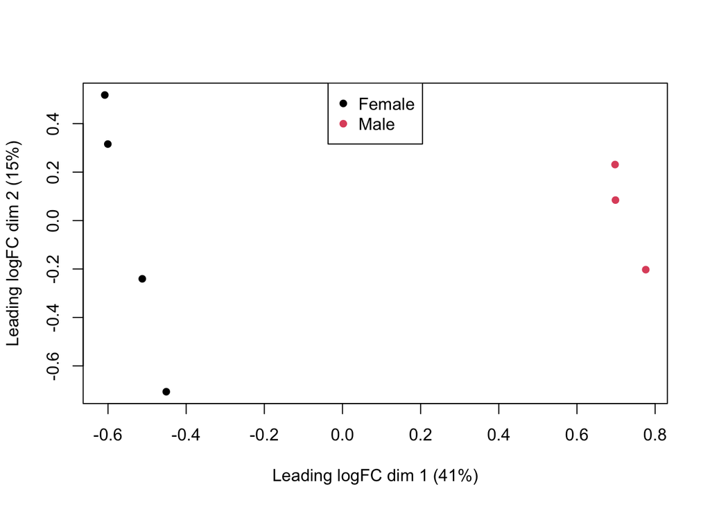

```r
plotMDS(dge0, col = as.numeric(dge0$samples$sex), labels = NULL, pch = 16)
legend("top", legend = levels(dge0$samples$sex), col = 1:2, pch = 16)
```

## 3.5 Model and inference

The model for gene $g$ in mouse $i$ is

$$\log \mu_{gi} = \beta_{g0} + \beta_{g,\text{M}}\, x_{i,\text{M}} + \log N^{\text{eff}}_i,$$

so $\beta_{g,\text{M}}$ is the log fold change between male and female mice.

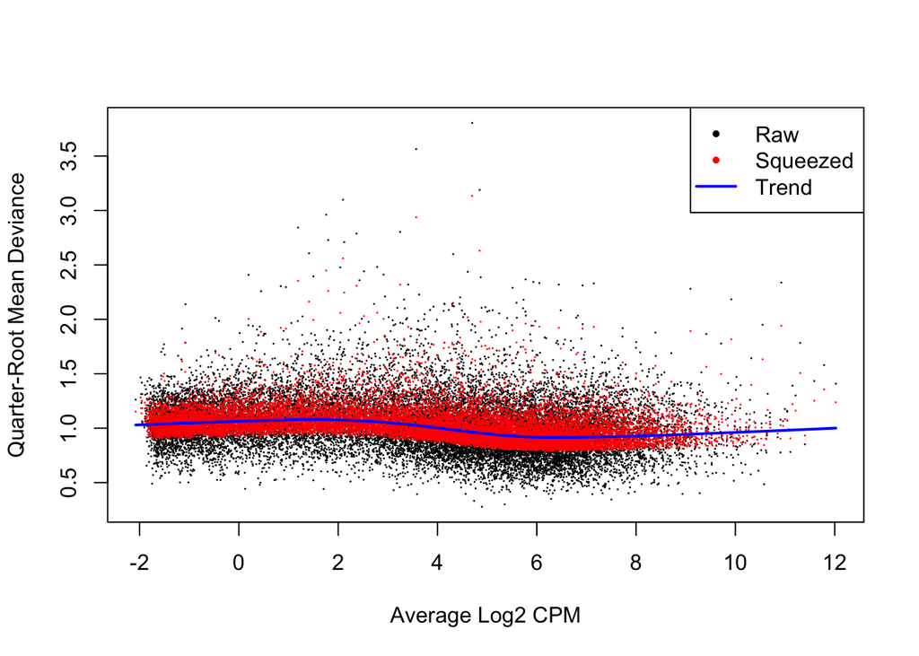

```r
fit0 <- glmQLFit(dge0, design0)
plotQLDisp(fit0)
```

```r
test0 <- glmQLFTest(fit0, coef = "sexMale")
summary(decideTests(test0))
```

```
       sexMale
Down         3
NotSig   17767
Up           9
```

```r
topTags(test0, n = 15)$table |>
  select(gene, seqnames, logFC, logCPM, F, FDR)
```

```
                     gene seqnames       logFC    logCPM          F
Ddx3y               Ddx3y        Y  12.7573752  5.701678 6426.49523
Uty                   Uty        Y  11.9241595  4.130446 2501.66779
Kdm5d               Kdm5d        Y  11.9693980  4.174804 1980.24265
Xist                 Xist        X -11.2461385  9.415086 1206.08094
Eif2s3y           Eif2s3y        Y  14.3152154  4.909021 3305.77275
LOC105243748 LOC105243748        Y   9.9113738  0.568023  374.39806
Kdm6a               Kdm6a        X  -0.7102280  6.286726  106.62540
LOC105243746 LOC105243746        Y   7.7840525 -1.378982  131.44029
Apold1             Apold1        6   1.2431056  2.838268   61.97025
Slc8a3             Slc8a3       12   0.4022243  5.462688   50.51414
Tob2                 Tob2       15   0.3257108  6.552889   49.75593
Ddx3x               Ddx3x        X  -0.5282095  9.193624   47.22067
Eif2s3x           Eif2s3x        X  -0.5667338  5.764912   41.76330
Zfp36               Zfp36        7   0.9315849  2.781467   41.74271
Srrm4               Srrm4        5   0.4395534  6.897946   37.63163
                      FDR
Ddx3y        1.201435e-17
Uty          3.885207e-11
Kdm5d        1.019858e-10
Xist         7.144266e-09
Eif2s3y      4.121698e-08
LOC105243748 1.780676e-04
Kdm6a        1.454616e-03
LOC105243746 7.366230e-03
Apold1       1.577468e-02
Slc8a3       3.564269e-02
Tob2         3.564269e-02
Ddx3x        4.140625e-02
Eif2s3x      6.152297e-02
Zfp36        6.152297e-02
Srrm4        9.030007e-02
```

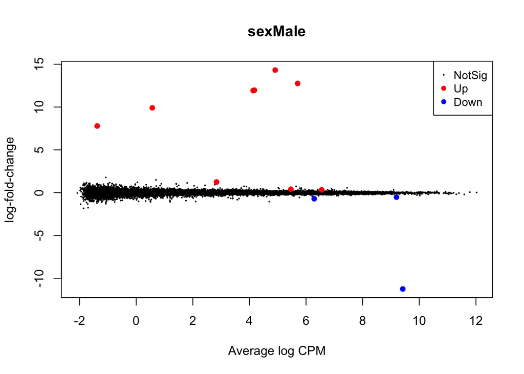

```r
plotMD(test0)
```

**TipQuestion**

- Did the positive control work?
- Why are the log fold changes of the Y-chromosomal genes and *Xist* so large?
- Some genes on the X chromosome other than *Xist* are significantly higher in females, but with a much smaller fold change. Can you explain this?
- Yes: the Y-chromosomal genes are only expressed in males, *Xist* only in females.
- These genes have (almost) no counts in the other sex, so their fold change is essentially infinite. edgeR adds a small prior count to keep the log fold changes finite.
- In female cells, one of the two X chromosomes is inactivated, but some genes, e.g. *Kdm6a*, *Ddx3x* and *Eif2s3x*, escape the X inactivation. They are expressed from both X chromosomes in females and from one in males.
- With only 3 and 4 mice, the power is low: we find the genes with huge effects, but subtle sex differences are missed.

# 4 The full experiment

We now analyse all mice.

## 4.1 Construct the DGEList

We store the counts, the sample information and the gene annotation in a `DGEList` object.

```r
dge <- DGEList(
  counts = counts,
  samples = coldata,
  genes = rowdata[match(rownames(counts), rowdata$gene),
                  c("gene", "seqnames", "ENTREZID", "gbkey")]
)
dim(dge)
```

```
[1] 41786    22
```

```r
head(dge$genes)
```

```
                     gene seqnames  ENTREZID gbkey
Xkr4                 Xkr4        1    497097  mRNA
LOC105243853 LOC105243853        1 105243853 ncRNA
LOC105242387 LOC105242387        1 105242387 ncRNA
LOC105242467 LOC105242467        1 105242467  mRNA
Rp1                   Rp1        1     19888  mRNA
Sox17               Sox17        1     20671  mRNA
```

## 4.2 Library sizes

A first quality check is the sequencing depth of the samples, i.e. the total number of counts per sample.

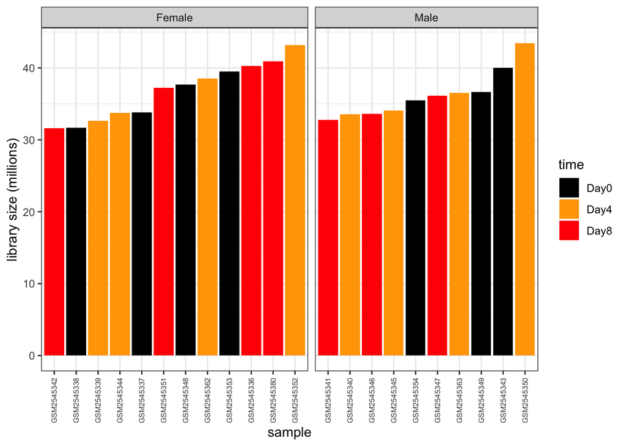

```r
dge$samples |>
  mutate(sample = colnames(dge), libSize = lib.size / 1e6) |>
  ggplot(aes(reorder(sample, libSize), libSize, fill = time)) +
  geom_col() +
  facet_grid(~ sex, scales = "free_x", space = "free_x") +
  scale_fill_manual(values = c(Day0 = "black", Day4 = "orange", Day8 = "red")) +
  xlab("sample") +
  ylab("library size (millions)") +
  theme_bw() +
  theme(axis.text.x = element_text(angle = 90, vjust = 0.5, hjust = 1, size = 6))
```

**TipQuestion**

- Are there samples with a much lower sequencing depth than the others?
- Are the library sizes related to sex or time? Why would that be a problem?
- The library sizes range from 32 to 43 million counts: no sample stands out.
- The library sizes are not related to sex or time. The offsets correct for differences in sequencing depth, but a strong association between depth and a factor of interest would make the depth correction critical for the conclusions and can point to technical differences between the groups, e.g. samples of one group processed in another batch.

## 4.3 Quality control of the sample information

Mistakes in the sample annotation happen. The sex of a sample can be checked with the expression of *Xist*, which is only expressed in female cells, and *Ddx3y*, which is located on the Y chromosome.

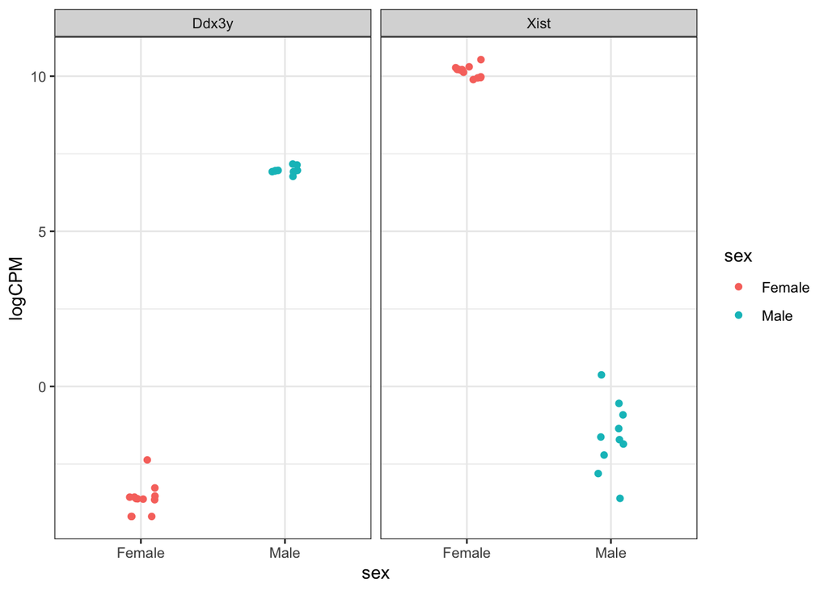

```r
tibble(
  sample = colnames(dge),
  sex = dge$samples$sex,
  Xist = cpm(dge, log = TRUE)["Xist", ],
  Ddx3y = cpm(dge, log = TRUE)["Ddx3y", ]
) |>
  pivot_longer(c(Xist, Ddx3y), names_to = "gene", values_to = "logCPM") |>
  ggplot(aes(sex, logCPM, colour = sex)) +
  geom_jitter(width = 0.1, height = 0) +
  facet_wrap(~ gene) +
  theme_bw()
```

The expression of both genes agrees with the recorded sex of all mice.

# 5 Filtering and normalisation

We remove genes with too few counts to be informative. `filterByExpr` uses the design to decide in how many samples a gene should be expressed. We use the design with the main effects of sex and time and their interaction, which we will discuss below.

```r
design <- model.matrix(~ sex * time, data = dge$samples)
keep <- filterByExpr(dge, design)
table(keep)
```

```
keep
FALSE  TRUE
22986 18800
```

```r
dge <- dge[keep, , keep.lib.sizes = FALSE]
```

We correct for differences in sequencing depth and RNA composition with TMM normalisation.

```r
dge <- normLibSizes(dge)
dge$samples |>
  select(sex, time, lib.size, norm.factors)
```

```
              sex time lib.size norm.factors
GSM2545336 Female Day8 40243933    1.0145594
GSM2545337 Female Day0 33804672    0.9746600
GSM2545338 Female Day0 31671148    0.9786578
GSM2545339 Female Day4 32648744    1.0129355
GSM2545340   Male Day4 33504552    1.0072282
GSM2545341   Male Day8 32761797    0.9817879
GSM2545342 Female Day8 31608436    1.0014987
GSM2545343   Male Day0 40014199    1.0108976
GSM2545344 Female Day4 33711321    1.0007860
GSM2545345   Male Day4 34029979    0.9923517
GSM2545346   Male Day8 33627717    1.0060423
GSM2545347   Male Day8 36112826    1.0112822
GSM2545348 Female Day0 37681882    1.0018640
GSM2545349   Male Day0 36627964    1.0036300
GSM2545350   Male Day4 43393432    0.9643113
GSM2545351 Female Day8 37204702    1.0148780
GSM2545352 Female Day4 43169540    1.0086447
GSM2545353 Female Day0 39503341    1.0086567
GSM2545354   Male Day0 35454441    0.9971157
GSM2545362 Female Day4 38526085    1.0178039
GSM2545363   Male Day4 36485602    0.9914970
GSM2545380 Female Day8 40902177    1.0010643
```

**TipQuestion**

The normalisation factors are all close to 1. What does that tell you?

# 6 Data exploration

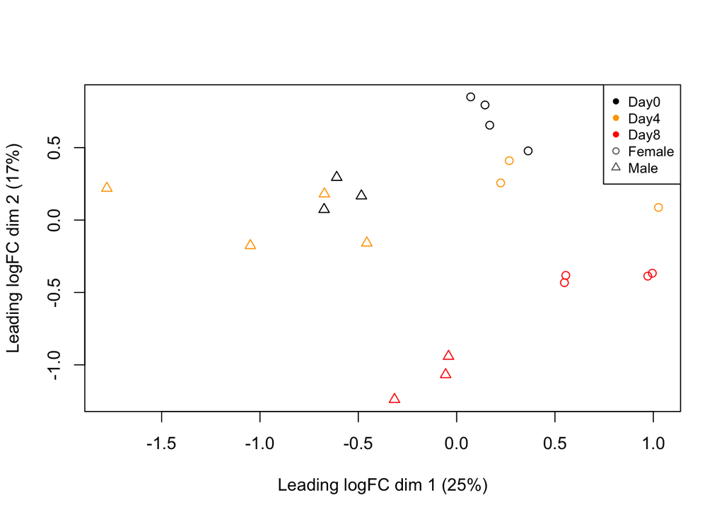

```r
timeCols <- c(Day0 = "black", Day4 = "orange", Day8 = "red")
plotMDS(dge, col = timeCols[dge$samples$time],
        pch = as.numeric(dge$samples$sex), labels = NULL)
legend("topright",
       legend = c(levels(dge$samples$time), levels(dge$samples$sex)),
       col = c(timeCols, "grey40", "grey40"), pch = c(16, 16, 16, 1, 2), cex = 0.8)
```

**TipQuestion**

- Which source of variability is captured by the first dimension, and which by the second?
- The sex effect involves only a handful of genes. Why can it still dominate a dimension of the MDS plot?
- The second dimension mainly separates the day-8 mice from the others.
- The first dimension mainly separates the female (circles) from the male (triangles) mice.
- The distance between two samples in the MDS plot is based on the 500 genes with the largest log fold changes between them. Genes on the sex chromosomes, e.g. *Xist* and the Y-chromosomal genes, have log fold changes of about 10 between females and males, so they dominate the distance between mice of different sex.

# 7 Design

We model the counts of gene $g$ in sample $i$ with a negative binomial GLM:

$$\log \mu_{gi} = \beta_{g0} + \beta_{g,\text{M}}\, x_{i,\text{M}} + \beta_{g,\text{D4}}\, x_{i,\text{D4}} + \beta_{g,\text{D8}}\, x_{i,\text{D8}} + \beta_{g,\text{M:D4}}\, x_{i,\text{M}} x_{i,\text{D4}} + \beta_{g,\text{M:D8}}\, x_{i,\text{M}} x_{i,\text{D8}} + \log N^{\text{eff}}_i,$$

with $x_{i,\text{M}}$, $x_{i,\text{D4}}$ and $x_{i,\text{D8}}$ indicator variables for male mice, day 4 and day 8, respectively, and $N^{\text{eff}}_i$ the effective library size.

```r
colnames(design)
```

```
[1] "(Intercept)"      "sexMale"          "timeDay4"         "timeDay8"
[5] "sexMale:timeDay4" "sexMale:timeDay8"
```

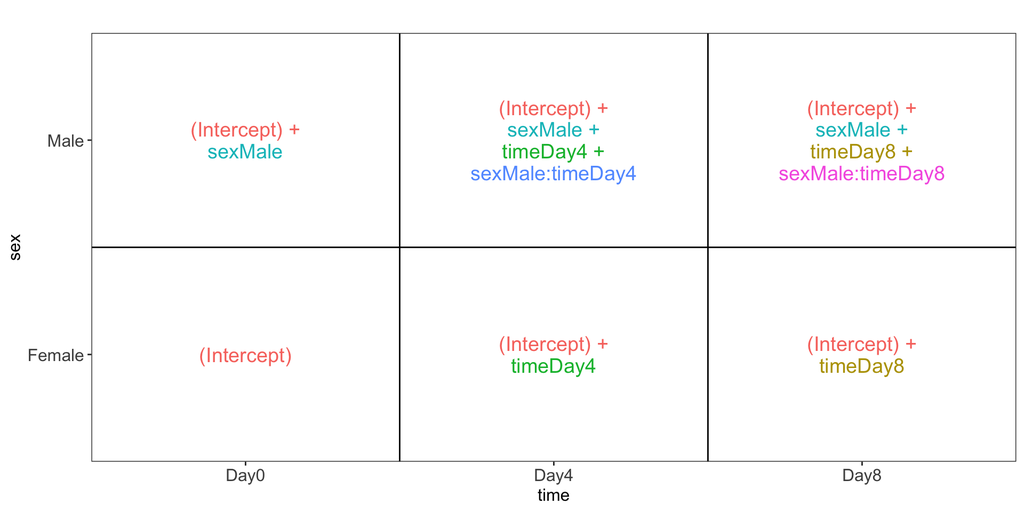

```r
vd <- VisualizeDesign(dge$samples, designFormula = ~ sex * time)
vd$plotlist[[1]]
```

**TipQuestion**

Write each research question as a linear combination of the model parameters.

The mean log expression in each of the six groups follows from the model (dropping the gene index and the offset):

|  | day 0 | day 4 | day 8 |
| --- | --- | --- | --- |
| female | $\beta_0$ | $\beta_0 + \beta_\text{D4}$ | $\beta_0 + \beta_\text{D8}$ |
| male | $\beta_0 + \beta_\text{M}$ | $\beta_0 + \beta_\text{M} + \beta_\text{D4} + \beta_\text{M:D4}$ | $\beta_0 + \beta_\text{M} + \beta_\text{D8} + \beta_\text{M:D8}$ |

The contrasts are differences between these group means:

|  | research question | contrast |
| --- | --- | --- |
| 1 | early effect in females | $\beta_\text{D4}$ |
|  | early effect in males | $\beta_\text{D4} + \beta_\text{M:D4}$ |
| 2 | late effect in females | $\beta_\text{D8}$ |
|  | late effect in males | $\beta_\text{D8} + \beta_\text{M:D8}$ |
| 3 | late vs early in females | $\beta_\text{D8} - \beta_\text{D4}$ |
|  | late vs early in males | $\beta_\text{D8} + \beta_\text{M:D8} - \beta_\text{D4} - \beta_\text{M:D4}$ |
| 4 | early effect, males vs females | $\beta_\text{M:D4}$ |
|  | late effect, males vs females | $\beta_\text{M:D8}$ |
|  | late vs early, males vs females | $\beta_\text{M:D8} - \beta_\text{M:D4}$ |
| 5 | average early effect | $\beta_\text{D4} + \frac{1}{2}\beta_\text{M:D4}$ |
|  | average late effect | $\beta_\text{D8} + \frac{1}{2}\beta_\text{M:D8}$ |
|  | average late vs early | $\beta_\text{D8} - \beta_\text{D4} + \frac{1}{2}(\beta_\text{M:D8} - \beta_\text{M:D4})$ |
| 6 | males vs females at day 0 | $\beta_\text{M}$ |

We build the contrast matrix $\mathbf{L}$ from the sex-specific effects: the interactions are the differences and the averages the means of the effects in males and females.

```r
contrastNames <- c(
  "early_F", "early_M", "late_F", "late_M", "lateVsEarly_F", "lateVsEarly_M",
  "early_MvsF", "late_MvsF", "lateVsEarly_MvsF",
  "early_avg", "late_avg", "lateVsEarly_avg",
  "sex_day0"
)
L <- matrix(0, nrow = ncol(design), ncol = length(contrastNames),
            dimnames = list(colnames(design), contrastNames))
L["timeDay4", "early_F"] <- 1
L[c("timeDay4", "sexMale:timeDay4"), "early_M"] <- 1
L["timeDay8", "late_F"] <- 1
L[c("timeDay8", "sexMale:timeDay8"), "late_M"] <- 1
for (sex in c("F", "M")) {
  L[, paste0("lateVsEarly_", sex)] <- L[, paste0("late_", sex)] - L[, paste0("early_", sex)]
}
for (effect in c("early", "late", "lateVsEarly")) {
  L[, paste0(effect, "_MvsF")] <- L[, paste0(effect, "_M")] - L[, paste0(effect, "_F")]
  L[, paste0(effect, "_avg")] <- (L[, paste0(effect, "_M")] + L[, paste0(effect, "_F")]) / 2
}
L["sexMale", "sex_day0"] <- 1
t(L)
```

```
                 (Intercept) sexMale timeDay4 timeDay8 sexMale:timeDay4
early_F                    0       0        1        0              0.0
early_M                    0       0        1        0              1.0
late_F                     0       0        0        1              0.0
late_M                     0       0        0        1              0.0
lateVsEarly_F              0       0       -1        1              0.0
lateVsEarly_M              0       0       -1        1             -1.0
early_MvsF                 0       0        0        0              1.0
late_MvsF                  0       0        0        0              0.0
lateVsEarly_MvsF           0       0        0        0             -1.0
early_avg                  0       0        1        0              0.5
late_avg                   0       0        0        1              0.0
lateVsEarly_avg            0       0       -1        1             -0.5
sex_day0                   0       1        0        0              0.0
                 sexMale:timeDay8
early_F                       0.0
early_M                       0.0
late_F                        0.0
late_M                        1.0
lateVsEarly_F                 0.0
lateVsEarly_M                 1.0
early_MvsF                    0.0
late_MvsF                     1.0
lateVsEarly_MvsF              1.0
early_avg                     0.0
late_avg                      0.5
lateVsEarly_avg               0.5
sex_day0                      0.0
```

# 8 Inference

We estimate the dispersions and fit the quasi-likelihood model of edgeR 4.

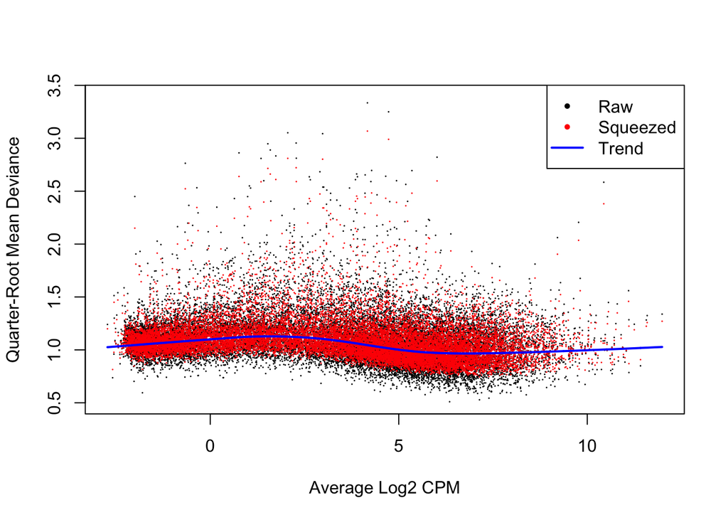

```r
fit <- glmQLFit(dge, design)
plotQLDisp(fit)
```

We assess every contrast with a QL F-test.

```r
tests <- lapply(colnames(L), function(contrast) glmQLFTest(fit, contrast = L[, contrast]))
names(tests) <- colnames(L)
countDE <- function(tests) {
  res <- t(sapply(tests, function(test) summary(decideTests(test))))
  colnames(res) <- c("Down", "NotSig", "Up")
  res
}
countDE(tests)
```

```
                 Down NotSig   Up
early_F             7  18774   19
early_M             1  18799    0
late_F           2517  13963 2320
late_M           1907  14958 1935
lateVsEarly_F     935  17010  855
lateVsEarly_M    1535  15621 1644
early_MvsF          0  18800    0
late_MvsF           0  18800    0
lateVsEarly_MvsF    0  18800    0
early_avg         128  18590   82
late_avg         3603  11599 3598
lateVsEarly_avg  2652  13469 2679
sex_day0            4  18789    7
```

The FDR is controlled at 5% for each contrast separately, not over all 13 contrasts together.

## 8.1 Effects of the infection in females and in males

- At day 4, 26 genes are DE in females and only 1 in males. At day 8, thousands of genes are DE in both sexes.
- Fewer genes are detected within one sex than for the average effects, because each sex-specific contrast is estimated with only 3 to 4 mice per group.

**TipQuestion**

At day 4, many more genes are DE in females than in males. Can we conclude that the early response to the infection is stronger in females, or that these genes only respond in females?

```r
table(
  females = decideTests(tests$early_F)[, 1],
  males = decideTests(tests$early_M)[, 1]
)
```

```
       males
females    -1     0
     -1     0     7
     0      1 18773
     1      0    19
```

```r
deOneSex <- xor(decideTests(tests$early_F)[, 1] != 0, decideTests(tests$early_M)[, 1] != 0)
table(significantInteraction = decideTests(tests$early_MvsF)[deOneSex, 1] != 0)
```

```
significantInteraction
FALSE
   27
```

- No. A difference in significance is not a significant difference.
- A gene can be just significant in one sex and just not significant in the other, while its fold changes are almost the same. With 3 to 4 mice per group, many truly responding genes are missed in each sex.
- Whether the effect differs between the sexes has to be tested directly with the interaction contrast. None of the 27 genes that are significant in only one sex has a significant interaction.
- We plot the early log fold changes in females and males for these genes.

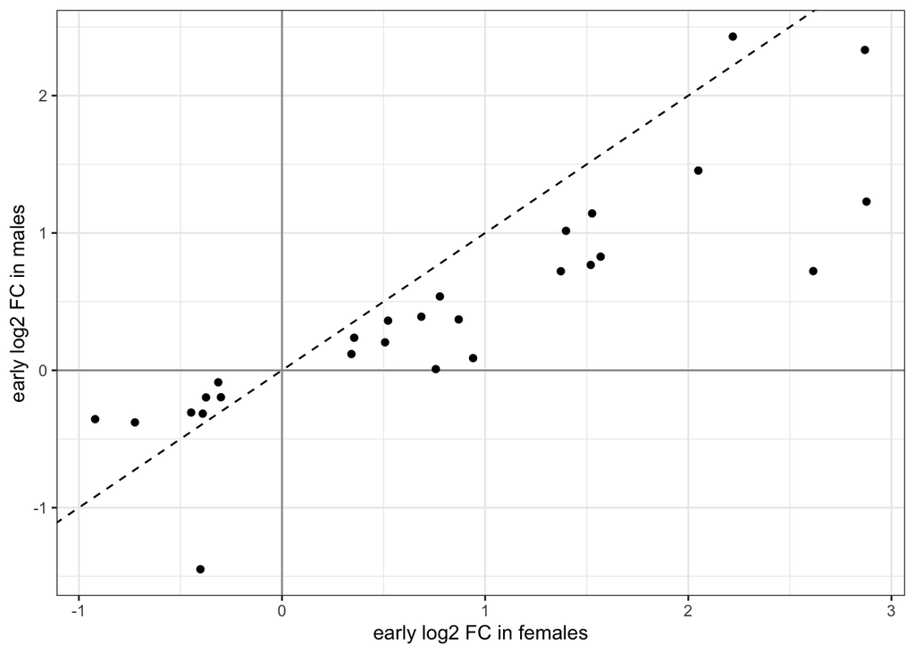

```r
tibble(
  gene = tests$early_F$genes$gene,
  females = tests$early_F$table$logFC,
  males = tests$early_M$table$logFC,
  deOneSex = deOneSex
) |>
  filter(deOneSex) |>
  ggplot(aes(females, males)) +
  geom_abline(slope = 1, intercept = 0, linetype = "dashed") +
  geom_hline(yintercept = 0, colour = "grey60") +
  geom_vline(xintercept = 0, colour = "grey60") +
  geom_point() +
  xlab("early log2 FC in females") +
  ylab("early log2 FC in males") +
  theme_bw()
```

- For almost all genes, the effect in males has the same sign as in females.
- The effects in males are often somewhat smaller, but the difference is not significant: with 3 to 4 mice per group, the estimated fold changes in each sex are noisy.
- Based on these data, we cannot claim that the early response differs between the sexes.

## 8.2 Sex $\times$ time interaction

The interaction contrasts test whether the effects of the infection differ between males and females.

```r
countDE(tests[c("early_MvsF", "late_MvsF", "lateVsEarly_MvsF")])
```

```
                 Down NotSig Up
early_MvsF          0  18800  0
late_MvsF           0  18800  0
lateVsEarly_MvsF    0  18800  0
```

The third interaction contrast is the difference between the first two: `lateVsEarly_MvsF` = `late_MvsF` $-$ `early_MvsF`. An omnibus test of whether the response to the infection differs between the sexes at any time point therefore has only 2 degrees of freedom: it tests whether both interaction parameters are zero.

```r
testInt <- glmQLFTest(fit, coef = c("sexMale:timeDay4", "sexMale:timeDay8"))
topTags(testInt, n = 5)
```

```
Coefficient:  sexMale:timeDay4 sexMale:timeDay8
                     gene seqnames  ENTREZID gbkey logFC.sexMale.timeDay4
Apold1             Apold1        6    381823  mRNA             -2.1293407
LOC102634887 LOC102634887        4 102634887 ncRNA             -2.1273184
Hoxd4               Hoxd4        2     15436  mRNA             -4.9288301
Lpo                   Lpo       11     76113  mRNA             -0.8080077
LOC105246608 LOC105246608       19 105246608 ncRNA             -2.2631341
             logFC.sexMale.timeDay8    logCPM        F       PValue       FDR
Apold1                   -1.8508460  2.665756 16.89804 3.347458e-05 0.6293221
LOC102634887             -1.5706277 -0.218965 14.53675 8.998652e-05 0.8458732
Hoxd4                     1.1299360 -2.479635 10.89247 2.323508e-04 0.8768224
Lpo                      -0.5451231  1.164964 11.50082 3.654556e-04 0.8768224
LOC105246608             -1.1062730 -1.600430 11.31643 4.068870e-04 0.8768224
```

```r
sum(p.adjust(testInt$table$PValue, method = "BH") < 0.05)
```

```
[1] 0
```

- We find no evidence that the response to the infection differs between female and male mice.
- This does not prove that the responses are the same: with 3 to 4 mice per group, the power to detect interactions is low.
- We do not drop the interaction from the model. Selecting a model based on a non-significant test uses the data twice and invalidates the p-values and the FDR of the subsequent tests. In omics, the model follows the design of the experiment and is chosen before looking at the data.

## 8.3 Average effects of the infection

```r
countDE(tests[c("early_avg", "late_avg", "lateVsEarly_avg")])
```

```
                Down NotSig   Up
early_avg        128  18590   82
late_avg        3603  11599 3598
lateVsEarly_avg 2652  13469 2679
```

- The average contrasts use all mice and therefore have more power than the sex-specific contrasts.
- They estimate the effect of the infection in a population with equal numbers of male and female mice, whether or not there is an interaction.
- If the interaction is large, however, the average effect is not a good summary: then the effects in the two sexes should be reported separately.

```r
topTags(tests$early_avg, n = 10)$table |>
  select(gene, logFC, logCPM, F, FDR)
```

```
               gene      logFC   logCPM        F          FDR
Itih3         Itih3  0.6575561 6.771999 66.32712 0.0006426741
Asl             Asl  0.4417494 4.281578 61.87795 0.0006426741
Lrg1           Lrg1  2.3246751 0.839801 56.46734 0.0009166054
Ifi27l2a   Ifi27l2a  2.6009952 1.337240 52.23348 0.0012862807
Enpp1         Enpp1 -0.3773506 3.824510 44.19573 0.0032713305
Rtp4           Rtp4  1.3344409 1.669834 43.61914 0.0032713305
Prodh         Prodh  0.4598460 5.522381 43.06402 0.0032713305
Trp53inp2 Trp53inp2 -0.3528170 8.080385 38.24576 0.0061398908
Ptgs2         Ptgs2  1.4508218 1.184668 38.22160 0.0061398908
Irf7           Irf7  1.2067507 2.086553 36.98802 0.0069905553
```

```r
topTags(tests$late_avg, n = 10)$table |>
  select(gene, logFC, logCPM, F, FDR)
```

```
                       gene      logFC    logCPM        F          FDR
Asl                     Asl  1.1179812  4.281578 384.1154 2.510391e-11
Apod                   Apod  1.4478063  9.019487 307.7344 1.301907e-10
Npcd                   Npcd  3.3666815 -2.589166 140.0214 2.033964e-10
Cyp2d22             Cyp2d22  0.9056958  6.141258 270.7183 2.033964e-10
Klk6                   Klk6 -1.6822734  3.923476 268.4986 2.033964e-10
A330076C08Rik A330076C08Rik -1.7669586  1.595417 265.4287 2.033964e-10
Tubb2b               Tubb2b -1.1664527  6.387160 243.6093 4.220820e-10
Slc2a4               Slc2a4  1.4235039  3.581431 235.9040 5.082082e-10
LOC105246405   LOC105246405  4.4567061 -1.652270 123.4625 5.082082e-10
Fcrls                 Fcrls -1.9527427  2.365274 215.9680 1.016785e-09
```

Thousands of genes are DE at day 8, many with a small fold change. With TREAT we only select genes whose fold change is significantly larger than 2, i.e. $|\log_2 \text{FC}| > 1$ (McCarthy and Smyth 2009).

```r
avgContrasts <- c("early_avg", "late_avg", "lateVsEarly_avg")
treat <- lapply(avgContrasts, function(contrast) glmTreat(fit, contrast = L[, contrast], lfc = 1))
names(treat) <- avgContrasts
countDE(treat)
```

```
                Down NotSig Up
early_avg          0  18800  0
late_avg          41  18711 48
lateVsEarly_avg    4  18787  9
```

**TipQuestion**

Compare the number of DE genes with the QL test and with TREAT. What does this tell you about the effect of the infection on the cerebellum?

- Only a small fraction of the DE genes at day 8 has a fold change that is significantly larger than 2.
- The infection takes place in the lungs: the effect on the brain is broad, but most changes are subtle.

## 8.4 Sex differences before the infection

```r
countDE(tests["sex_day0"])
```

```
         Down NotSig Up
sex_day0    4  18789  7
```

```r
topTags(tests$sex_day0, n = 10)$table |>
  select(gene, seqnames, logFC, logCPM, FDR)
```

```
                     gene seqnames       logFC     logCPM          FDR
Ddx3y               Ddx3y        Y  12.7581827  5.8402884 2.517763e-31
Eif2s3y           Eif2s3y        Y  14.3224397  5.2853301 6.130198e-23
Uty                   Uty        Y  11.9260417  4.2080513 1.928290e-20
Xist                 Xist        X -11.2460692  9.2892588 9.052341e-17
Kdm5d               Kdm5d        Y  11.9711886  4.2602754 3.441917e-16
LOC105243748 LOC105243748        Y   9.9185471  0.5979954 6.407101e-09
Kdm6a               Kdm6a        X  -0.7110621  6.2953973 1.087542e-03
LOC105243746 LOC105243746        Y   7.7914380 -1.0573024 2.503586e-03
Ddx3x               Ddx3x        X  -0.5289517  9.2737723 5.508236e-03
Eif2s3x           Eif2s3x        X  -0.5677399  5.8099448 1.156045e-02
```

The genes that differ between female and male mice before the infection are located on the sex chromosomes.

**TipQuestion**

The contrast `sex_day0` in the full model and the warm-up analysis address the same research question with the same day-0 mice. The full model estimates the dispersions with all 22 mice instead of 7. Would you expect it to detect more genes? Does it?

```r
data.frame(
  analysis = c("warm-up (day 0 only)", "full model"),
  DEgenes = c(sum(decideTests(test0) != 0), sum(decideTests(tests$sex_day0) != 0)),
  dfResidual = c(fit0$df.residual[1], fit$df.residual[1])
)
```

```
              analysis DEgenes dfResidual
1 warm-up (day 0 only)      12          5
2           full model      11         16
```

- The log fold change between the sexes at day 0 only uses the day-0 mice in both analyses.
- The full model estimates the dispersion of each gene with 16 instead of 5 residual degrees of freedom, which should increase the power.
- Yet the full model does not detect more genes. The extra degrees of freedom only help if the dispersion is the same in all groups. We estimate the common biological coefficient of variation (BCV, the square root of the NB dispersion) separately for each time point:

```r
bcvTime <- sapply(levels(dge$samples$time), function(tp) {
  dgeTime <- normLibSizes(dge[, dge$samples$time == tp])
  designTime <- model.matrix(~ sex, data = dgeTime$samples)
  sqrt(estimateDisp(dgeTime, designTime)$common.dispersion)
})
round(bcvTime, 3)
```

```
 Day0  Day4  Day8
0.081 0.126 0.102
```

- The infected mice are more variable than the non-infected mice, e.g. because the severity of the infection differs between mice.
- The full model assumes a common dispersion for all groups. For the comparison at day 0, the pooled dispersion is too large, which costs more power than the extra degrees of freedom gain.
- Conversely, the tests on the infected groups use a dispersion that is somewhat too small.
- Heterogeneous variability between groups is common in omics experiments, e.g. between treated and untreated samples or between tissues. Always check it, e.g. by comparing the dispersions of separate fits per group.

# 9 Visualisation

```r
statusColors <- c("not significant" = "grey60", "QL test only" = "orange",
                  "QL test and TREAT" = "red")
deStatus <- tibble(
  logFC = tests$late_avg$table$logFC,
  logCPM = tests$late_avg$table$logCPM,
  PValue = tests$late_avg$table$PValue,
  FDR = p.adjust(tests$late_avg$table$PValue, method = "BH"),
  FDRtreat = p.adjust(treat$late_avg$table$PValue, method = "BH")
) |>
  mutate(status = case_when(
    FDRtreat < 0.05 ~ "QL test and TREAT",
    FDR < 0.05 ~ "QL test only",
    TRUE ~ "not significant"
  ) |> factor(levels = names(statusColors)))
table(deStatus$status)
```

```
  not significant      QL test only QL test and TREAT
            11599              7112                89
```

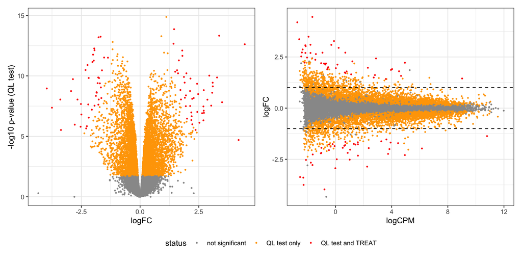

```r
volcano <- ggplot(deStatus, aes(logFC, -log10(PValue), colour = status)) +
  geom_point(size = 0.5) +
  scale_colour_manual(values = statusColors) +
  ylab("-log10 p-value (QL test)") +
  theme_bw()
md <- ggplot(deStatus, aes(logCPM, logFC, colour = status)) +
  geom_point(size = 0.5) +
  geom_hline(yintercept = c(-1, 1), linetype = "dashed") +
  scale_colour_manual(values = statusColors) +
  theme_bw()
volcano + md + plot_layout(guides = "collect") & theme(legend.position = "bottom")
```

The heatmap shows the 30 genes with the smallest p-value in the TREAT analysis of the average late effect.

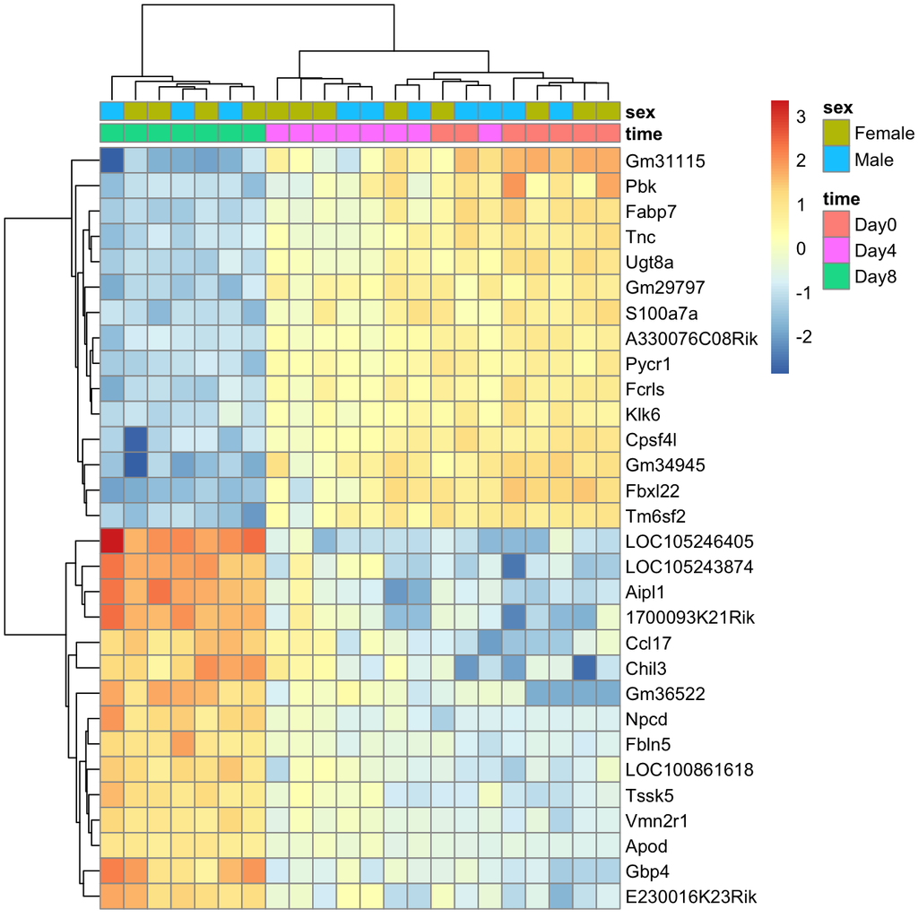

```r
topGenes <- rownames(topTags(treat$late_avg, n = 30))
logCPM <- cpm(dge, log = TRUE)[topGenes, ]
pheatmap::pheatmap(
  logCPM - rowMeans(logCPM),
  scale = "none",
  annotation_col = data.frame(time = dge$samples$time, sex = dge$samples$sex,
                              row.names = colnames(dge)),
  show_colnames = FALSE
)
```

**TipQuestion**

Do the day-4 mice cluster with the day-0 or with the day-8 mice for these genes? Is that what you expect from the number of DE genes at day 4 and at day 8?

# 10 Gene set analysis

Which biological processes are affected by the infection? We perform an over-representation analysis of GO biological processes with `goana`, separately for up- and down-regulated genes. The few TREAT genes give too little information for an ORA, so we use the genes that are significant in the QL test. The universe consists of the genes that passed the filtering.

```r
goTime <- lapply(c("early_avg", "late_avg"), function(contrast) {
  tt <- topTags(tests[[contrast]], n = Inf)$table |>
    filter(!is.na(ENTREZID))
  deGenes <- list(
    Up = tt |> filter(FDR < 0.05, logFC > 0) |> pull(ENTREZID),
    Down = tt |> filter(FDR < 0.05, logFC < 0) |> pull(ENTREZID)
  )
  goana(deGenes, universe = tt$ENTREZID, species = "Mm") |>
    filter(Ont == "BP", N >= 10, N <= 500)
})
names(goTime) <- c("early", "late")
```

```r
topGO(goTime$early, sort = "Up", number = 10, truncate.term = 45)
```

```
                                                    Term Ont   N Up Down
GO:0009615                             response to virus  BP 352 20    1
GO:0051607                     defense response to virus  BP 272 17    1
GO:0035456                   response to interferon-beta  BP  63 10    0
GO:0034340                 response to type I interferon  BP  75 10    0
GO:0140888         interferon-mediated signaling pathway  BP  86 10    0
GO:0048525          negative regulation of viral process  BP  63  9    0
GO:0071357        cellular response to type I interferon  BP  68  9    0
GO:0060337 type I interferon-mediated signaling pathw...  BP  68  9    0
GO:0050792                   regulation of viral process  BP 125 10    0
GO:0035455                  response to interferon-alpha  BP  29  6    0
                   P.Up    P.Down
GO:0009615 4.177746e-17 0.9136413
GO:0051607 2.601174e-15 0.8486968
GO:0035456 1.633169e-13 1.0000000
GO:0034340 1.015390e-12 1.0000000
GO:0140888 4.172414e-12 1.0000000
GO:0048525 7.684868e-12 1.0000000
GO:0071357 1.572077e-11 1.0000000
GO:0060337 1.572077e-11 1.0000000
GO:0050792 1.821437e-10 1.0000000
GO:0035455 2.639783e-09 1.0000000
```

```r
topGO(goTime$early, sort = "Down", number = 10, truncate.term = 45)
```

```
                                                    Term Ont   N Up Down
GO:0042552                                   myelination  BP 174  0   12
GO:0008366                             axon ensheathment  BP 176  0   12
GO:0007272                       ensheathment of neurons  BP 176  0   12
GO:0048709               oligodendrocyte differentiation  BP 124  0   10
GO:0045229 external encapsulating structure organizat...  BP 308  5   13
GO:0030198             extracellular matrix organization  BP 308  5   13
GO:0043062          extracellular structure organization  BP 309  5   13
GO:0007229           integrin-mediated signaling pathway  BP 101  1    8
GO:0085029                 extracellular matrix assembly  BP  50  1    6
GO:0042063                                   gliogenesis  BP 374  1   13
                 P.Up       P.Down
GO:0042552 1.00000000 2.783003e-09
GO:0008366 1.00000000 3.169670e-09
GO:0007272 1.00000000 3.169670e-09
GO:0048709 1.00000000 1.379517e-08
GO:0045229 0.01156795 2.060262e-07
GO:0030198 0.01156795 2.060262e-07
GO:0043062 0.01171854 2.138353e-07
GO:0007229 0.36019460 4.704289e-07
GO:0085029 0.19810753 1.157722e-06
GO:0042063 0.81100403 1.837755e-06
```

```r
topGO(goTime$late, sort = "Up", number = 10, truncate.term = 45)
```

```
                                                    Term Ont   N Up Down
GO:0002706    regulation of lymphocyte mediated immunity  BP 151 56   10
GO:0002709        regulation of T cell mediated immunity  BP  80 35    4
GO:0002697         regulation of immune effector process  BP 313 96   36
GO:0002703     regulation of leukocyte mediated immunity  BP 210 70   19
GO:0002449                  lymphocyte mediated immunity  BP 234 76   22
GO:0002822 regulation of adaptive immune response bas...  BP 172 60   17
GO:0035456                   response to interferon-beta  BP  63 29    3
GO:0002705 positive regulation of leukocyte mediated ...  BP 122 46   10
GO:0001906                                  cell killing  BP 163 57   21
GO:0002443                   leukocyte mediated immunity  BP 329 98   37
                   P.Up    P.Down
GO:0002706 1.766916e-07 0.9999973
GO:0002709 3.944776e-07 0.9999508
GO:0002697 5.536862e-07 0.9999202
GO:0002703 6.765652e-07 0.9999858
GO:0002449 7.320236e-07 0.9999890
GO:0002822 7.561789e-07 0.9997334
GO:0035456 1.068164e-06 0.9998190
GO:0002705 1.253811e-06 0.9997921
GO:0001906 1.292133e-06 0.9877626
GO:0002443 1.826471e-06 0.9999690
```

```r
topGO(goTime$late, sort = "Down", number = 10, truncate.term = 45)
```

```
                                                    Term Ont   N Up Down
GO:0033490 cholesterol biosynthetic process via latho...  BP  20  1   15
GO:0033489 cholesterol biosynthetic process via desmo...  BP  21  3   15
GO:0008360                      regulation of cell shape  BP 136 14   47
GO:0006457                               protein folding  BP 184 21   59
GO:0010001                    glial cell differentiation  BP 280 43   79
GO:0036197               zymosterol biosynthetic process  BP  16  3   10
GO:0036196                  zymosterol metabolic process  BP  16  3   10
GO:0008366                             axon ensheathment  BP 176 27   53
GO:0007272                       ensheathment of neurons  BP 176 27   53
GO:0042552                                   myelination  BP 174 27   52
                P.Up       P.Down
GO:0033490 0.9857386 1.009974e-07
GO:0033489 0.7952167 2.903138e-07
GO:0008360 0.9983205 1.681815e-05
GO:0006457 0.9983161 2.111030e-05
GO:0010001 0.9580313 1.520529e-04
GO:0036197 0.6154412 1.729695e-04
GO:0036196 0.6154412 1.729695e-04
GO:0008366 0.9196125 3.236524e-04
GO:0007272 0.9196125 3.236524e-04
GO:0042552 0.9086215 4.480032e-04
```

**TipQuestion**

Interpret the GO terms. How does the response of the cerebellum change between day 4 and day 8?

- At day 4, the up-regulated genes are enriched for the response to type I interferons and the defence against viruses: the innate immune response.
- At day 8, the up-regulated genes are enriched for lymphocyte and T-cell mediated immunity and cell killing: the adaptive immune response.
- Genes involved in myelination, oligodendrocyte differentiation and cholesterol biosynthesis, which is needed to build myelin, are down-regulated. This agrees with Blackmore et al. (2017), who studied whether an influenza infection can trigger demyelinating disease.

# 11 Further exercises

1. Test whether male and female mice also differ at day 4 and at day 8. Which genes do you expect?
2. We tested 13 contrasts per gene and controlled the FDR per contrast. Use a stage-wise approach instead: first an omnibus F-test of all time and interaction parameters per gene, then the individual contrasts only for the genes that pass the screening stage (see the stageR package and the technical details chapter).

## References

Blackmore, Stephen, Jessica Hernandez, Michal Juda, et al. 2017. “Influenza Infection Triggers Disease in a Genetic Model of Experimental Autoimmune Encephalomyelitis.” *Proceedings of the National Academy of Sciences* 114 (30): E6107–16. https://doi.org/10.1073/pnas.1620415114.

McCarthy, Davis J, and Gordon K Smyth. 2009. “Testing Significance Relative to a Fold-Change Threshold Is a TREAT.” *Bioinformatics* 25 (6): 765–71. https://doi.org/10.1093/bioinformatics/btp053.